# PracticalHW1:DecisionTrees

## Multi-Class: # days used marijuana in past year

```r
### Random Forest
# regrouping data
df <- df %>%
  mutate(MRJYDAYS_CAT = case_when(
    marijuana_days_past_year_cat == 6 ~ "Never",
    marijuana_days_past_year_cat %in% c(1, 2) ~ "Occasional",
    marijuana_days_past_year_cat %in% c(3, 4, 5) ~ "Frequent"
  )) %>%
  mutate(MRJYDAYS_CAT = factor(MRJYDAYS_CAT))
table(df$MRJYDAYS_CAT)
```

```
##
##   Frequent      Never Occasional
##        566       9226        769
```

```r
# Define variables
vars <- c(
  'sex',                          # IRSEX
  'race_ethnicity',              # NEWRACE2
  'self_reported_health',        # HEALTH2
  'current_grade',               # EDUSCHGRD2
  'household_income',            # INCOME
  'mother_in_household',         # IMOTHER
  'population_density',          # PDEN10
  'MRJYDAYS_CAT')

# Subset and clean data
df_tree <- df %>%
  select(all_of(vars)) %>%
  drop_na() %>%
  mutate(MRJYDAYS_CAT = as.factor(MRJYDAYS_CAT))


# balance data
set.seed(123)
df_balanced <- RandUnderClassif(MRJYDAYS_CAT ~ ., df_tree)
table(df_balanced$MRJYDAYS_CAT)
```

```
##
##   Frequent      Never Occasional
##        566        566        566
```

```r
# train test split
set.seed(123)
train_idx <- sample(1:nrow(df_balanced), nrow(df_balanced)*0.7)
train <- df_balanced[train_idx, ]
test <- df_balanced[-train_idx, ]

# fit random forest model
set.seed(123)
rf_tree <- randomForest(MRJYDAYS_CAT ~., data = train, mtry = 3, importance = TRUE)
rf_tree
```

```
##
## Call:
##  randomForest(formula = MRJYDAYS_CAT ~ ., data = train, mtry = 3,      importance = TRUE)
##                Type of random forest: classification
##                      Number of trees: 500
## No. of variables tried at each split: 3
##
##         OOB estimate of  error rate: 54.88%
## Confusion matrix:
##            Frequent Never Occasional class.error
## Frequent        168    83        132   0.5613577
## Never            95   212        102   0.4816626
## Occasional      141    99        156   0.6060606
```

```r
# fit random forest model (minimum variables)
set.seed(123)
rf_model_min <- randomForest(MRJYDAYS_CAT ~., data = train, mtry = 1, importance = TRUE)
rf_model_min
```

```
##
## Call:
##  randomForest(formula = MRJYDAYS_CAT ~ ., data = train, mtry = 1,      importance = TRUE)
##                Type of random forest: classification
##                      Number of trees: 500
## No. of variables tried at each split: 1
##
##         OOB estimate of  error rate: 52.44%
## Confusion matrix:
##            Frequent Never Occasional class.error
## Frequent        170    89        124   0.5561358
## Never            72   251         86   0.3863081
## Occasional      128   124        144   0.6363636
```

```r
# fit random forest model (maximum variables)
all_predictors <-  length(train)-1
set.seed(123)
bag_model <- randomForest(MRJYDAYS_CAT ~., data = train, mtry = all_predictors, importance = TRUE)
bag_model
```

```
##
## Call:
##  randomForest(formula = MRJYDAYS_CAT ~ ., data = train, mtry = all_predictors,      importance = TRUE)
##                Type of random forest: classification
##                      Number of trees: 500
## No. of variables tried at each split: 7
##
##         OOB estimate of  error rate: 56.4%
## Confusion matrix:
##            Frequent Never Occasional class.error
## Frequent        175    86        122   0.5430809
## Never           101   204        104   0.5012225
## Occasional      138   119        139   0.6489899
```

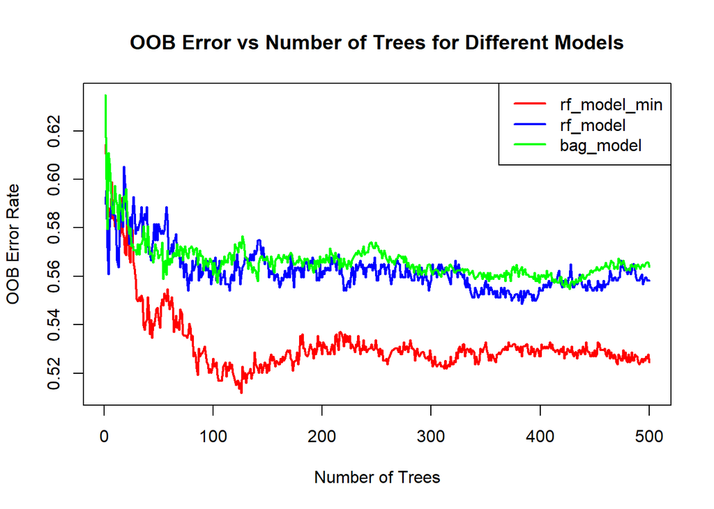

```r
### Comparing errors for different mtry values

# extract OOB errors for each model
oob_min <- rf_model_min$err.rate[, "OOB"]
oob_mid <- rf_model$err.rate[, "OOB"]
oob_bag <- bag_model$err.rate[, "OOB"]

# plot error vs number of trees
plot(oob_min, type = 'l', col = 'red', lwd = 2, xlab = 'Number of Trees', ylab = 'OOB Error Rate', main = 'OOB Error vs Number of Trees for Different Models', ylim = range(c(oob_min, oob_mid, oob_bag), na.rm = TRUE))

lines(oob_mid, col = 'blue', lwd = 2)
lines(oob_bag, col = 'green', lwd = 2)

legend("topright", legend = c("rf_model_min", "rf_model", "bag_model"),col = c("red", "blue", "green"), lwd = 2)
```

```r
# importance
importance(rf_model_min)
```

```
##                        Frequent     Never Occasional MeanDecreaseAccuracy
## sex                   0.3785368 11.320316   2.715954             8.795205
## race_ethnicity        0.9773086  1.977639   3.047066             3.452290
## self_reported_health 16.2842588 17.714705   5.439447            20.405331
## current_grade        14.4539385 27.323945  12.202945            26.488304
## household_income      1.9282240 -2.096753   7.153881             4.150304
## mother_in_household   3.8956335  5.642199   2.178806             6.676435
## population_density    7.2955695  0.726922   5.261885             7.793499
##                      MeanDecreaseGini
## sex                          8.755478
## race_ethnicity              20.127839
## self_reported_health        21.846178
## current_grade               41.801662
## household_income            13.408119
## mother_in_household          7.676137
## population_density          11.028060
```

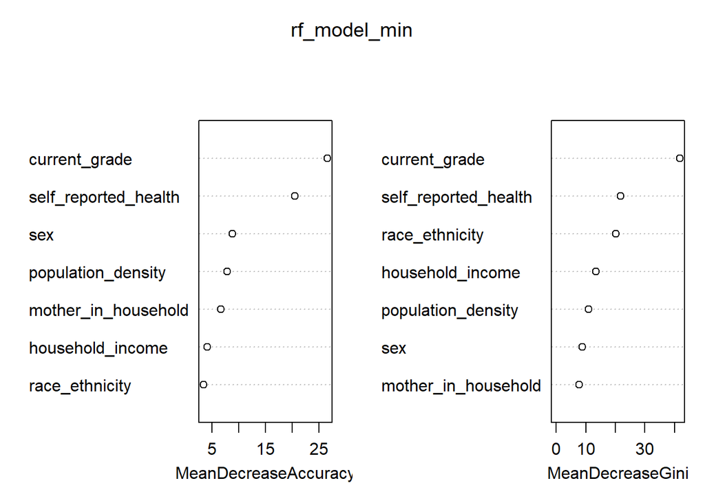

```r
varImpPlot(rf_model_min)
```

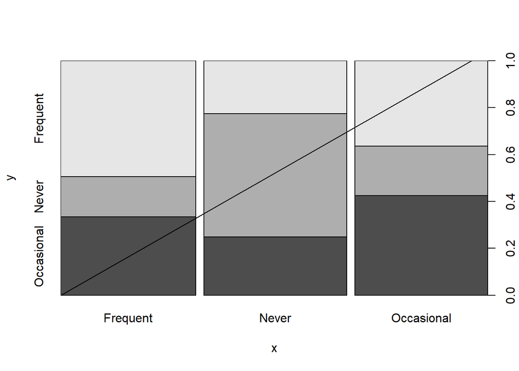

```r
# predict on test data
yhat.bag <- predict(rf_model_min, newdata = test)
plot(yhat.bag, test$MRJYDAYS_CAT) # plot points
abline(0, 1) # plot regression line
```

```r
# accuracy
mean(yhat.bag == test$MRJYDAYS_CAT)
```

```
## [1] 0.4823529
```

```r
# mse
mse <- mean((as.numeric(test$MRJYDAYS_CAT) - as.numeric(yhat.bag))^2)
mse
```

```
## [1] 1.2
```

## Regression Classification: Age of First Usage

A regression classification model that predicts the age in which youths first used marijuana could be useful in helping schools understand at what age or grade level to implement resources and awareness towards drug use.

The following model examines from only students who used marijuana, what factors can help predict the age of first use. From the regression tree, we can see that mainly grade level and race are prevalent factors in predicting age of first marijuana use. The rmse measures the average difference between predicted and actual values in years, in terms of this model means that the model can on average predict the age of a participants first use of marijuana within 1.8 years.

The regression model shows that on the younger side, youths are exposed to marijuana at around 11-12 years old, but 13-14 year olds are more typical perhaps. This result might incline schools to start drug use awareness and safety at around 5th grade and continue to emphasize the importance of awareness through middle and high school.

```r
### REGRESSION MODEL
# clean target variable (IRMJAGE)
df <- df %>%
  filter(marijuana_first_use_age != 991) %>%  # remove "never used"
  mutate(marijuana_first_use_age = as.numeric(marijuana_first_use_age)) %>%
  drop_na()

# Define variables
vars <- c(
  'sex',                     # IRSEX
  'race_ethnicity',          # NEWRACE2
  'self_reported_health',    # HEALTH2
  'current_grade',           # EDUSCHGRD2
  'household_income',        # INCOME
  'population_density',      # PDEN10
  'marijuana_first_use_age'  # IRMJAGE
)

# Subset and clean data
df_tree <- df %>%
  select(all_of(vars)) %>%
  drop_na()

# train test split
set.seed(123)
train_idx <- sample(1:nrow(df_tree), nrow(df_tree)*0.7)
train <- df_tree[train_idx, ]
test <- df_tree[-train_idx, ]

# fit regression classification
set.seed(123)
reg_tree <- tree(marijuana_first_use_age ~ ., data = train)
summary(reg_tree)
```

```
##
## Regression tree:
## tree(formula = marijuana_first_use_age ~ ., data = train)
## Variables actually used in tree construction:
## [1] "current_grade"  "race_ethnicity"
## Number of terminal nodes:  6
## Residual mean deviance:  2.524 = 2350 / 931
## Distribution of residuals:
##    Min. 1st Qu.  Median    Mean 3rd Qu.    Max.
## -9.9300 -0.7853  0.2147  0.0000  1.1470  3.1470
```

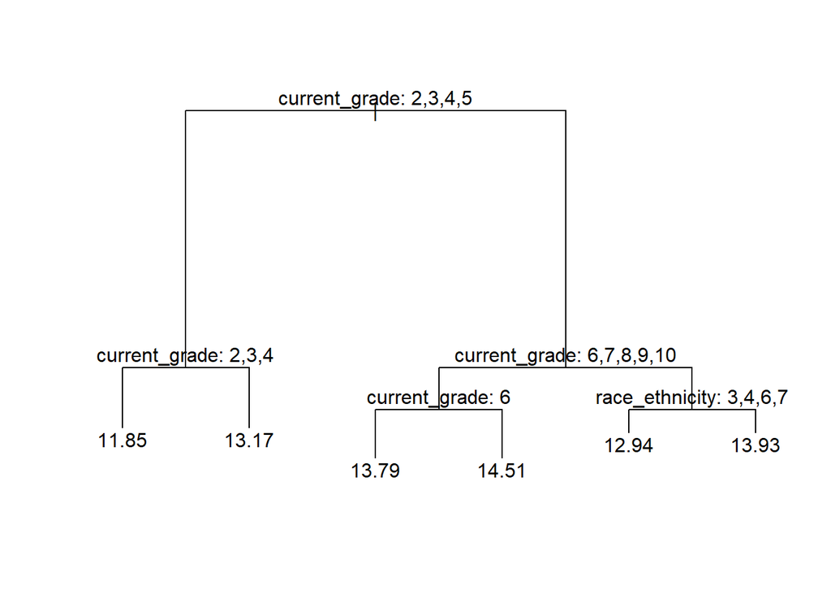

```r
# plot regression tree
plot(reg_tree)
text(reg_tree, pretty = 0)
```

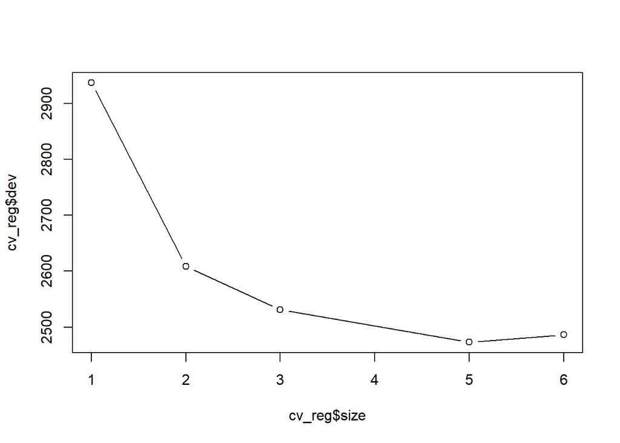

```r
# prune tree
set.seed(123)
cv_reg <- cv.tree(reg_tree)
plot(cv_reg$size, cv_reg$dev, type = "b")
```

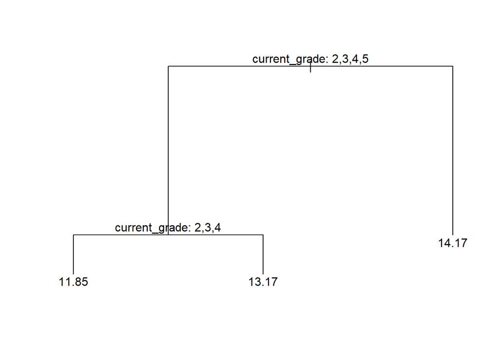

```r
# pruned tree
prune_reg <- prune.tree(reg_tree, best = 3)
plot(prune_reg)
text(prune_reg, pretty = 0)
```

```r
# predict on tree
yhat <- predict(prune_reg, newdata = test)

# rmse
mse <- mean((yhat - test$marijuana_first_use_age)^2)
sqrt(mse)
```

```
## [1] 1.857506
```

A boosting model can help learn additional nuances of the data. We implemented a boosting regression model that tested different values on lambda on the training set, and chose the optimal lambda of 0.1 as the shrinkage value to run our final model but with an rmse of about the same (1.76 years accuracy), the results are about the same as a simpler model. It would make more sense to use a regular regression classification tree in this scenario, as it takes less computational power and produces about the same result.

```r
### BOOSTING REGRESSION MODEL
# boosting model (regression)
library(gbm)
```

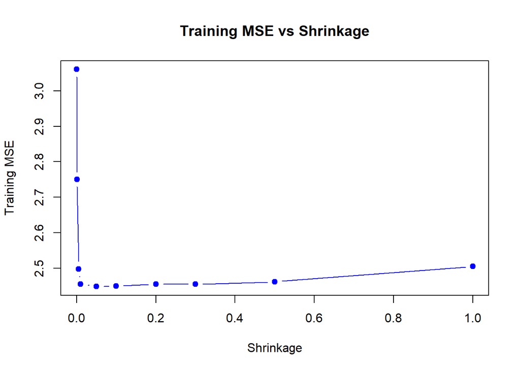

```r
set.seed(123)

# define shrinkage values
shrinkage_values <- c(0.0001, 0.001, 0.005, 0.01, 0.05, 0.1, 0.2, 0.3, 0.5, 1)

# store training mse
train_mse <- numeric(length(shrinkage_values))

# loop over shrinkage values
for (i in seq_along(shrinkage_values)) {
  lambda <- shrinkage_values[i]

  boost_model <- gbm(marijuana_first_use_age ~ ., data = train, distribution = "gaussian", n.trees = 1000, shrinkage = lambda)

  pred_train <- predict(boost_model, newdata = train, n.trees = 1000)

  train_mse[i] <- mean((pred_train - train$marijuana_first_use_age)^2)
}

# plot training MSE vs shrinkage
plot(shrinkage_values, train_mse, type = "b", pch = 19, col = "blue", xlab = "Shrinkage", ylab = "Training MSE", main = "Training MSE vs Shrinkage")
```

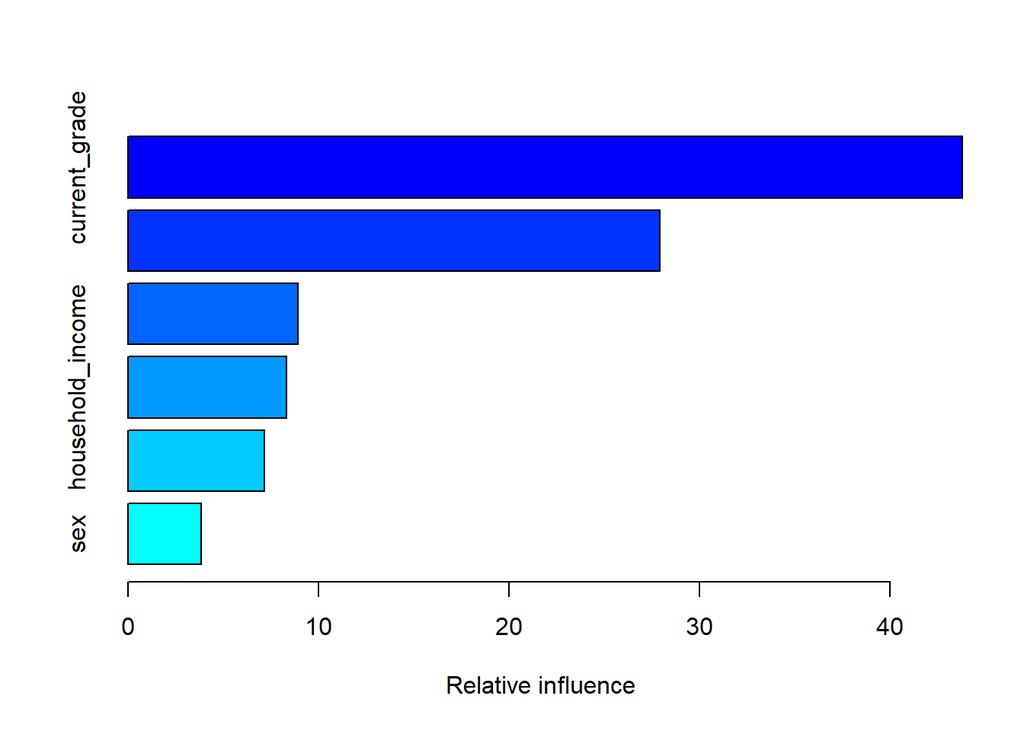

```
##                                       var   rel.inf
## current_grade               current_grade 43.805289
## race_ethnicity             race_ethnicity 27.925246
## self_reported_health self_reported_health  8.912860
## household_income         household_income  8.338501
## population_density     population_density  7.170565
## sex                                   sex  3.847540
```

```r
## bosting model
boost_reg <- gbm(marijuana_first_use_age ~ ., data = train,
    distribution = "gaussian", n.trees = 1000, shrinkage = 0.1)
summary(boost_reg)
```

```r
# predict on test data
yhat.boost <- predict(boost_reg,
    newdata = test, n.trees = 1000)

# mse
mse <- mean((yhat.boost - test$marijuana_first_use_age)^2)
sqrt(mse)
```

```
## [1] 1.757587
```